# Exercise3

Compute an ordinary linear regression of I versus C. Does the income depend on the number of cows?

```r
farm <- read.table("farm.dat", header = TRUE)
farm.fit <- lm(Dollar ~ cows, data=farm)
summary(farm.fit)
```

```
##
## Call:
## lm(formula = Dollar ~ cows, data = farm)
##
## Residuals:
##     Min      1Q  Median      3Q     Max
## -204.68  -80.02   15.48   54.57  284.43
##
## Coefficients:
##             Estimate Std. Error t value Pr(>|t|)
## (Intercept)  694.019     50.039  13.869 4.75e-11 ***
## cows          20.111      4.725   4.256 0.000475 ***
## ---
## Signif. codes:  0 '***' 0.001 '**' 0.01 '*' 0.05 '.' 0.1 ' ' 1
##
## Residual standard error: 122.9 on 18 degrees of freedom
## Multiple R-squared:  0.5016, Adjusted R-squared:  0.4739
## F-statistic: 18.11 on 1 and 18 DF,  p-value: 0.0004751
```

The p-value of the regression coefficient is very small (***) thus shows that the Income explains very well the number of cows.

Give the confidence intervals for the expected income without any cows, with 20 cows, and with C = 8.85 cows.

```r
predict(farm.fit, newdata=data.frame(cows=c(0,20,8.85)), interval="confidence")
```

```
##         fit      lwr       upr
## 1  694.0189 588.8902  799.1476
## 2 1096.2361 971.3953 1221.0768
## 3  872.0000 814.2627  929.7373
```

Compute an ordinary linear regression of I versus A and a multiple linear regression of I versus A and C. Also compute the correlation between A and C. Finally, based on your results, explain the differences between the three regression models.

First, we fit the Income vs Acres

```r
fitAI <- lm(Dollar~acres, data=farm)
summary(fitAI)
```

```
##
## Call:
## lm(formula = Dollar ~ acres, data = farm)
##
## Residuals:
##     Min      1Q  Median      3Q     Max
## -281.54 -113.94  -28.18   94.28  387.05
##
## Coefficients:
##             Estimate Std. Error t value Pr(>|t|)
## (Intercept) 868.7363   105.9796   8.197 1.73e-07 ***
## acres         0.0234     0.7066   0.033    0.974
## ---
## Signif. codes:  0 '***' 0.001 '**' 0.01 '*' 0.05 '.' 0.1 ' ' 1
##
## Residual standard error: 174.1 on 18 degrees of freedom
## Multiple R-squared:  6.09e-05,   Adjusted R-squared:  -0.05549
## F-statistic: 0.001096 on 1 and 18 DF,  p-value: 0.974
```

There is no significance (*) between the income and the acres. We add Cows as a covariate of Acres (Does income explain Acres + Cows?).

```r
fitAIC <- lm(Dollar~acres+cows, data=farm)
summary(fitAIC)
```

```
##
## Call:
## lm(formula = Dollar ~ acres + cows, data = farm)
##
## Residuals:
##      Min       1Q   Median       3Q      Max
## -145.064  -46.719   -9.992   55.149  133.664
##
## Coefficients:
##             Estimate Std. Error t value Pr(>|t|)
## (Intercept) 285.4572    81.3793   3.508   0.0027 **
## acres         2.1384     0.3936   5.434 4.47e-05 ***
## cows         32.5690     3.7276   8.737 1.08e-07 ***
## ---
## Signif. codes:  0 '***' 0.001 '**' 0.01 '*' 0.05 '.' 0.1 ' ' 1
##
## Residual standard error: 76.45 on 17 degrees of freedom
## Multiple R-squared:  0.8179, Adjusted R-squared:  0.7965
## F-statistic: 38.17 on 2 and 17 DF,  p-value: 5.165e-07
```

As covariate, both Acres and Cows are significant.

```r
corCA <- cor(farm$cows, farm$acres); corCA
```

```
## [1] -0.615085
```

To have a nice overview:

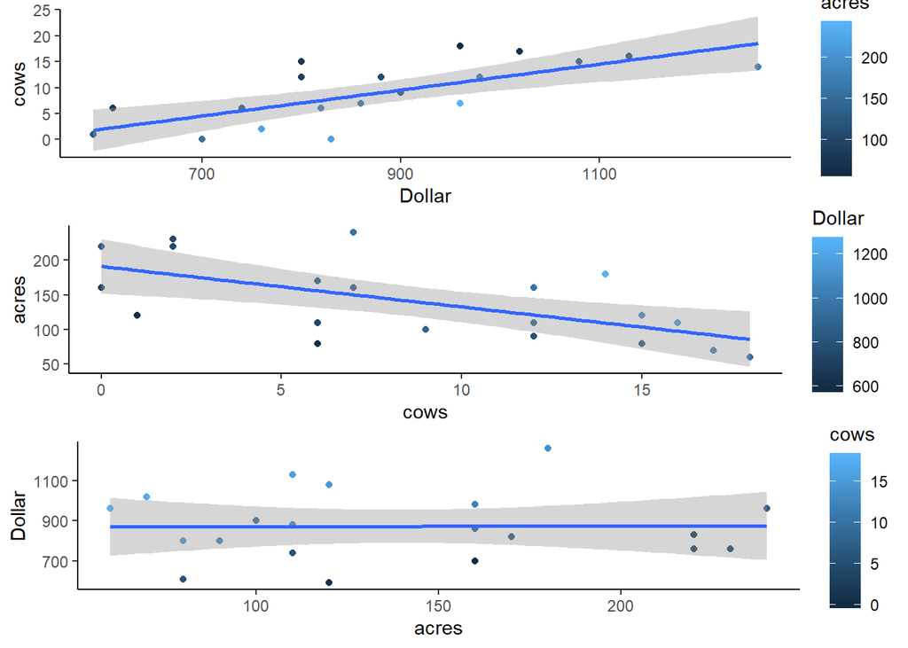